class: inverse, middle, center

# Visual Encodings

## Visual encodings can be categorized into the main groups below

.center[

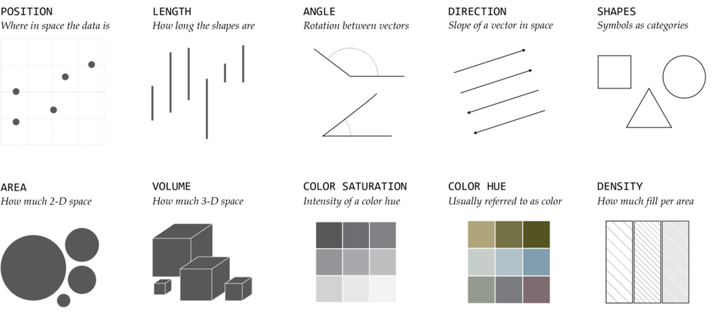

]

.small[All visualizations use some combination of these]

## Example: a *scatterplot* uses position on an x-y scale

.center[

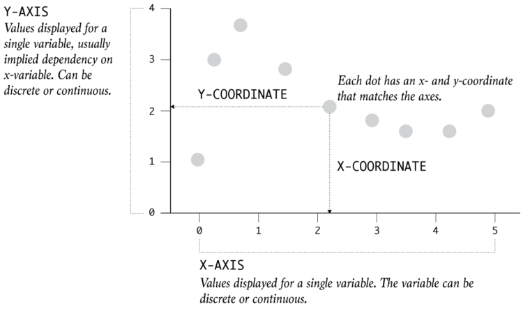

]

## A *bar chart* uses length to show values

.center[

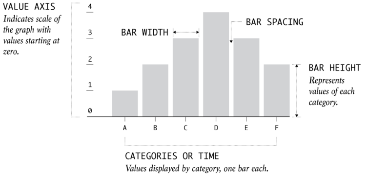

]

## Some encodings work better than others

.pull-left[

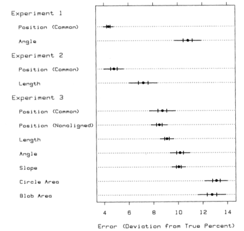

]

.pull-right[ **Decoding Error** 1. Position along a common scale 1. Length 1. Angle and slope 1. Area 1. Volume, density, and color saturation 1. Color hue]

## Position

*Position* allows you to compare values based on where they are placed with reference to a coordinate system.

### Considerations

- Avoid overplotting since many points can occupy the same space and obscure one another

### Solutions

- Use *transparency* so that overlapping points make darker areas
- Use *jitter* (adding noise that moves points so they are not directly on top of another)

## Length

*Length* is most commonly used in the context of bar charts. The longer a bar is, the greater the value. **Don’t truncate bar charts, use length in its entirety!**

–

.left-column70[ .small[**BAD:** FOX News, again!]

[figure not shown]

]

.right-column30[ .small[**GOOD**]

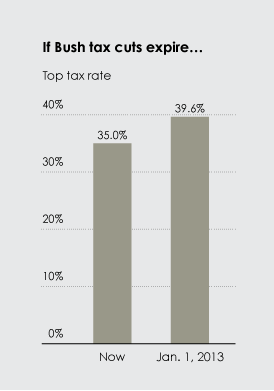

]

.small[FOX news, again…]

## Angle

*Angles* range from 0 to 360 degrees in a circle.

.left-column30[ ### Considerations

- Angles are most associated with *pie charts*. Pie chart is made up of parts that make up a whole.
- Don’t use too many categories (bar chart is better)
- **The sum of all percentages should equal 100%!** ]

–

.right-column70[ .small[NOT!]

[figure not shown]

]

## Slope

*Slope* is similar to *angle*. Line charts are the most common use of slope to encode data.

.left-column30[ ### Considerations

- Slope magnitude: steeper = greater change, flatter = lesser change
- The aspect ratio
- Visual change should match the context of the change

]

–

.right-column70[

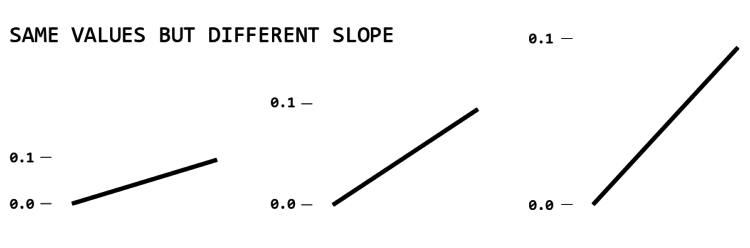

] —

## Area

Like *length*, *area* can be used to represent data with size, but with two dimensions instead of one.

.left-column30[ ### Considerations * While the encoding might not be as precise from a visual perception perspective, area can provide a more intuitive, less abstract view for some types of data * Make sure you scale by area, not edge (remember, area gets squared per unit increase)]

.right-column70[

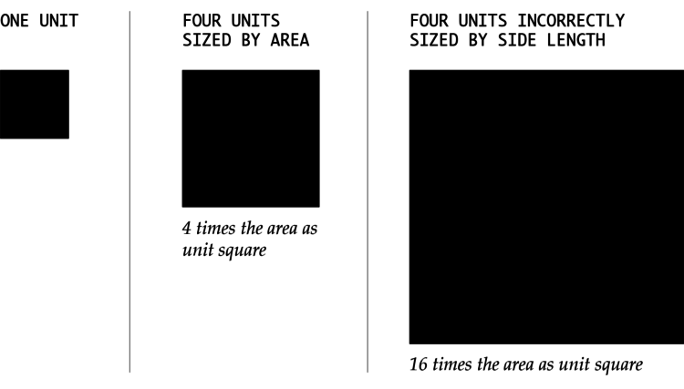

]

## A *treemap* uses rectangle areas to show hierarchical data

.center[

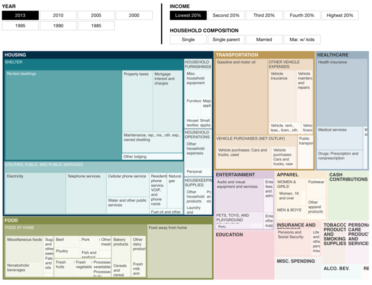

]

## Volume

*Volume* can used in the same way as *area* but has one more dimension.

.left-column30[ ### Considerations * Make sure you scale by volume, not edge (remember, volume gets cubed per unit increase) * ]

.right-column70[

[figure not shown]

]

## The volume, or 3D perspective representation can make tangible data more relatable

.center[

[figure not shown]

]

## Color

*Color* as a visual encoding can be split into two categories: **hue** and **saturation**. **Hue** is what most people refer to as color (red, green, blue, etc.) **Saturation** is the amount of **hue** in a color.

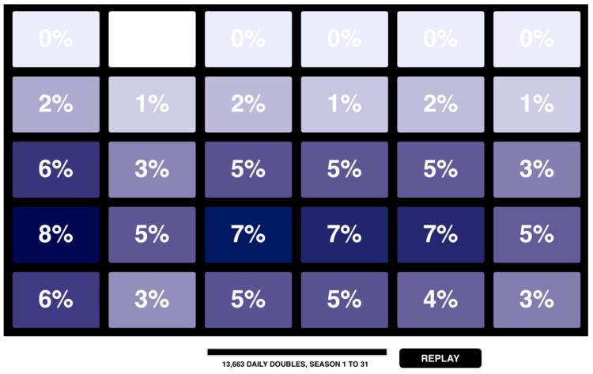

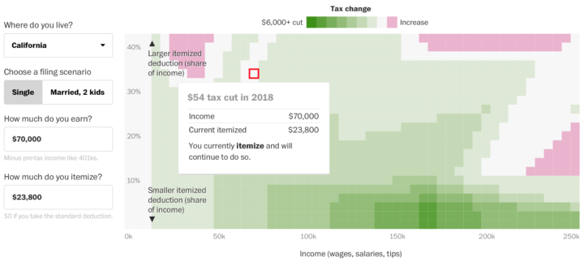

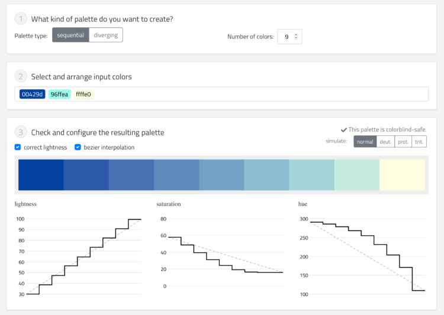

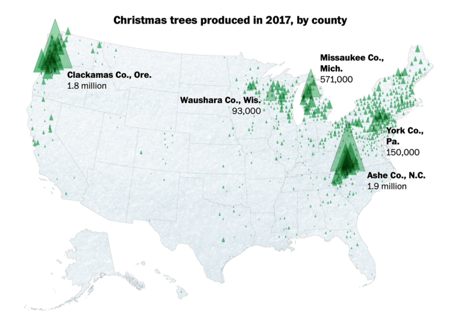

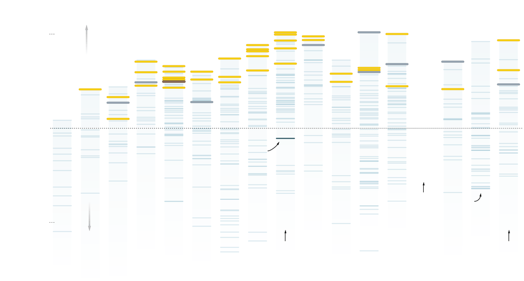

## In summary, work with the following attributes to encode your data

.pull-left[

- Position
- Length
- Angle
- Slope
- Area

]

.pull-right[

- Volume
- Color
- Density *
- Shape *

]

Or any combination thereof!

.small[* not discussed today]